# Description and Analysis of Prediction Models

Vahan Babushkin

Saturday, August 23, 2014

## Assignment

The project aims to analyse the input from different devices, placed on 6 participants’ bodies, who were asked to perform one set of 10 repetitions in order to evaluate the way they perform exercises. Participants’ performance is classified in 5 categories: “A”,“B”,“C”,“D”,“E”, stored in the classe variable.

- Class A– participants, following the specification,
- Class B – participants, throwing the elbows to the front ,
- Class C – lifting the dumbbell only halfway,
- Class D – lowering the dumbbell only halfway,
- Class E –throwing the hips to the front (Class E).

Read more: http://groupware.les.inf.puc-rio.br/har#weight_lifting_exercises#ixzz3BCucY9Vw

## Data Preprocessing

The columns, containing more than 95% of NAs and missing values were excluded from consideration. The data in pml-training.csv had bin split in proportion of 60/40 to form the training and testing sets. Data from pml-testing.csv has been preprocessed the same way and used for submission of predictions.

## Feature Selection

To determine the trends, the hystogram of features for each category were plotted. The features which hystograms are clearly separated were selected (e.g. see the figure below)

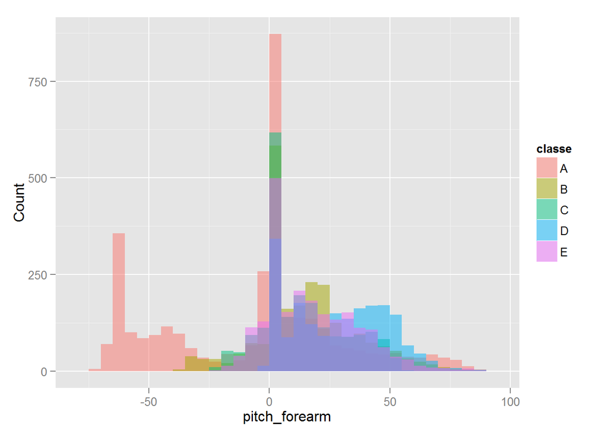

Also, features have been plotted against each other to see the relationship betwen them. For example, we can see some linear correlation between different categories of yaw_dumbbell and accel_dumbbell_z features:

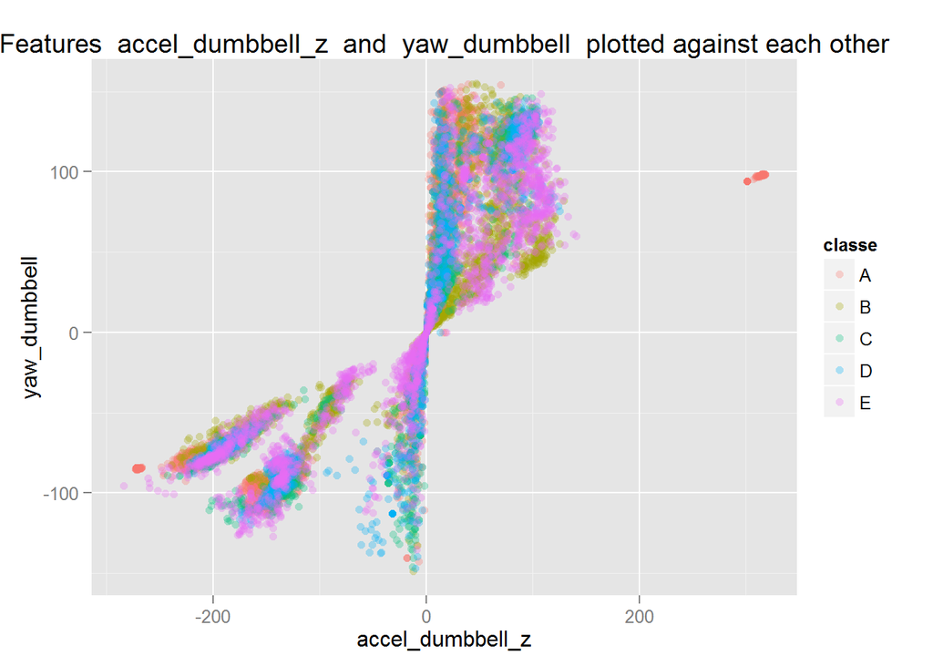

For the same purpose a scatter plot of different pairs of features can also been considered, e.g, we can note a linear correlation between accel_arm_y and accel_arm_z variables:

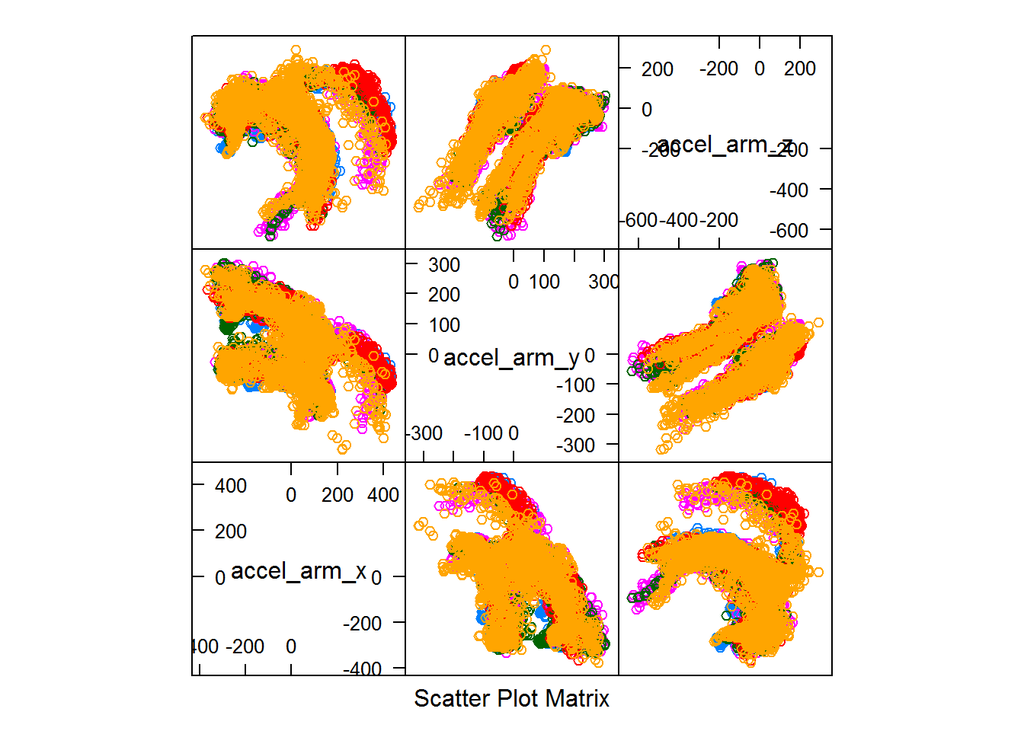

The following colums have been selected as quite reliable features:

- accel_arm_x,
- accel_arm_y,
- accel_arm_z,
- accel_belt_z,
- accel_dumbbell_x,
- accel_dumbbell_y,
- accel_dumbbell_z,
- accel_forearm_x,
- accel_forearm_y,
- accel_forearm_z,
- magnet_forearm_x,
- magnet_forearm_y,
- magnet_forearm_z,
- pitch_belt,
- pitch_dumbbell,
- pitch_forearm,
- roll_arm,
- roll_belt,
- roll_dumbbell,
- roll_forearm,
- yaw_arm,
- yaw_belt,
- yaw_dumbbell,
- yaw_forearm

## Models Used

Two models have been used: Linear Discriminant Analysis and a Gradiend Boosting Method. Both were tested on remaining 40% of training data. The linear classifier demonstrated poor performance with prediction accuracy of 50%, mostly, due to overfitting. It was able to correctly classify only 11 out of 20 instances of testing data (pml-testing.csv).

```
Confusion Matrix and Statistics

          Reference
Prediction    A    B    C    D    E
         A 1573  342  357  130  196
         B   89  593  102   58  324
         C  213  265  689   94  236
         D  266  128  115  829  195
         E   91  190  105  175  491

Overall Statistics

               Accuracy : 0.5321
                 95% CI : (0.521, 0.5432)
    No Information Rate : 0.2845
    P-Value [Acc > NIR] : < 2.2e-16

                  Kappa : 0.4056
 Mcnemar's Test P-Value : < 2.2e-16

Statistics by Class:

                     Class: A Class: B Class: C Class: D Class: E
Sensitivity            0.7047  0.39065  0.50365   0.6446  0.34050
Specificity            0.8174  0.90945  0.87527   0.8927  0.91240
Pos Pred Value         0.6055  0.50858  0.46025   0.5408  0.46673
Neg Pred Value         0.8744  0.86153  0.89305   0.9276  0.86002
Prevalence             0.2845  0.19347  0.17436   0.1639  0.18379
Detection Rate         0.2005  0.07558  0.08782   0.1057  0.06258
Detection Prevalence   0.3311  0.14861  0.19080   0.1954  0.13408
Balanced Accuracy      0.7611  0.65005  0.68946   0.7687  0.62645
```

However, the boosting clasifier was able to achieve 94% accuracy. The training with boosting predictor required more time to produce classification, and it was able to correctly classify all 20 instances of testing data (pml-testing.csv).

```
Confusion Matrix and Statistics

          Reference
Prediction    A    B    C    D    E
         A 2185   57    4    9    7
         B   21 1392   74   13   28
         C   15   56 1261   55   19
         D   10    6   27 1209   17
         E    1    7    2    0 1371

Overall Statistics

               Accuracy : 0.9454
                 95% CI : (0.9402, 0.9504)
    No Information Rate : 0.2845
    P-Value [Acc > NIR] : < 2.2e-16

                  Kappa : 0.931
 Mcnemar's Test P-Value : 4.102e-14

Statistics by Class:

                     Class: A Class: B Class: C Class: D Class: E
Sensitivity            0.9789   0.9170   0.9218   0.9401   0.9508
Specificity            0.9863   0.9785   0.9776   0.9909   0.9984
Pos Pred Value         0.9660   0.9110   0.8969   0.9527   0.9928
Neg Pred Value         0.9916   0.9801   0.9834   0.9883   0.9890
Prevalence             0.2845   0.1935   0.1744   0.1639   0.1838
Detection Rate         0.2785   0.1774   0.1607   0.1541   0.1747
Detection Prevalence   0.2883   0.1947   0.1792   0.1617   0.1760
Balanced Accuracy      0.9826   0.9478   0.9497   0.9655   0.9746
```

## References

Velloso, E.; Bulling, A.; Gellersen, H.; Ugulino, W.; Fuks, H. Qualitative Activity Recognition of Weight Lifting Exercises. Proceedings of 4th International Conference in Cooperation with SIGCHI (Augmented Human ’13) . Stuttgart, Germany: ACM SIGCHI, 2013.

Read more: http://groupware.les.inf.puc-rio.br/har#weight_lifting_exercises

http://mlarocca.github.io/07-23-2014/analysis.html